# GAM From Scratch Markdown

Thomas Wolff

2025-01-14

```r
#### Using the cubic spline basis
#### STEP 1: Read in data

library(ISLR)
library(mgcv)
par(mfrow=c(1,1))

# size <- c(1.42,1.58,1.78,1.99,1.99,1.99,2.13,2.13,2.13,
#           2.32,2.32,2.32,2.32,2.32,2.43,2.43,2.78,2.98,2.98)
# target <- c(4.0,4.2,2.5,2.6,2.8,2.4,3.2,2.4,2.6,4.8,2.9,
#           3.8,3.0,2.7,3.1,3.3,3.0,2.8,1.7)

size <- c(lapply(Wage['age'], as.numeric))
target <- c(lapply(Wage['wage'], as.numeric))

xs <- size$age-min(size$age);
x <- xs/max(xs)

ys <- Wage$wage-min(Wage$wage);
target <- ys/max(ys)
```

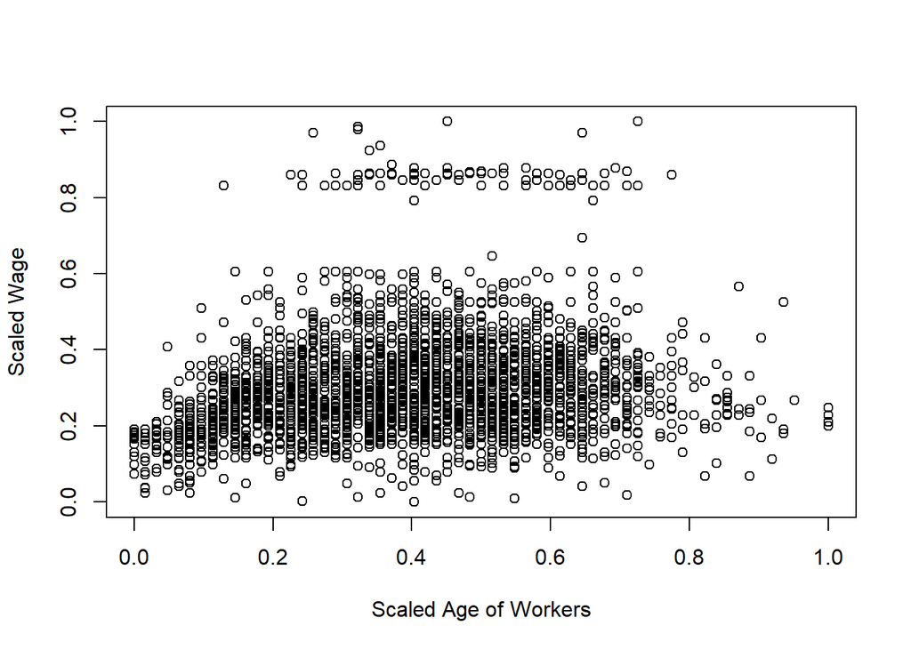

```r
## Plot x and y by Scaled x:
plot(x,target,xlab="Scaled Age of Workers",ylab="Scaled Wage")
```

## R Markdown

Establish the basis for the cubic spline function. This is the Gu equation. This function serves to return the matrix values for columns 3 through q in the model matrix

```r
## Column 1 is all 1
## Column 2 is all x
rk <- function(x,z) # R(x,z) for the cubic spline on [0,1]
{
  #print(((z-0.5)^2-1/12) * ((x-0.5)^2-1/12)/4-((abs(x-z)-0.5)^4-(abs(x-z)-0.5)^2/2+7/240)/24)
  return(((z-0.5)^2-1/12) * ((x-0.5)^2-1/12)/4-((abs(x-z)-0.5)^4-(abs(x-z)-0.5)^2/2+7/240)/24)
}
```

## Producing model matrix from sequence of knots

This function accepts a sequence of knots and an array of x values to produce model matrix for the spline

```r
spl.X <- function(x,xk)
  # Set up the model matrix for cubic penalized regression spline
{
  q <- length(xk)+2 # number of parameters
  n <- length(x) # number of data
  X <- matrix(1,n,q) # initialized model matrix
  X[,2] <- x # set second column to x
  X[,3:q] <- outer(x,xk,FUN=rk) # and remaining columns to R(x,xk)
  return(X)
}
```

```r
xk <- c(0.25,0.38,0.53,0.75)  # knots from quantile(x) command
X <- spl.X(x,xk) # generate model matrix
mod.1 <- lm(target~X-1) # fit model
xp <- 0:100/100    # x values for prediction
Xp <- spl.X(xp,xk) # prediction matrix
#plot(x,target,xlab="Scaled engine size",ylab="Wear index")
#line(xp,Xp%*%coef(mod.1)) # plot fitted spline
```

## Controlling smoothing

Here we control the degree of smoothing with penalized regression splines We obtain S, the matrix for the 2nd derivative of the curve

```r
spl.S <- function(xk)
# set up the penalized regression spline penalty matrix, given knot sequence xk
  # Function returns the matrix of the 2nd derivative of the curve
{
  q <- length(xk) + 2; S<-matrix(0,q,q) # initialize the matrix to 0
  S[3:q,3:q] <- outer(xk,xk,FUN=rk)
  return(S)
}

# Returning the square root of the derivative matrix above
mat.sqrt <-function(S)
{
  d <- eigen(S, symmetric = TRUE)
  rS <- d$vectors%*%diag(d$values^0.5)%*%t(d$vectors)
}
```

## Fitting the penalized regression spline to x,y data

```r
prs.fit <- function(y,x,xk,lambda)
# function to fit penalized regression spline to x,y data
# with knot locations xk, given smoothing parameter lambda
{
  q <- length(xk) + 2 # dimension of basis
  n <- length(x) # number of data rows
  # create augmented model matrix
  Xa <- rbind(spl.X(x,xk), mat.sqrt(spl.S(xk))*sqrt(lambda)) # max.sqrt(spl.S(xk)) is the penalty
  y[(n+1):(n+q)] <- 0 # augment the data vector
  return(lm(y~Xa-1)) # fit and return penalized regression spline
}
```

```r
# xk <- 1:7/8
# mod.2 <- prs.fit(wear,x,xk,0.001)
# Xp <- spl.X(xp,xk) # matrix to map params to fitted values at xp
# plot(x,wear);lines(xp,Xp%*%coef(mod.2)) # plot data and sql fit
```

## GCV for finding optimal Smoothing Parameter

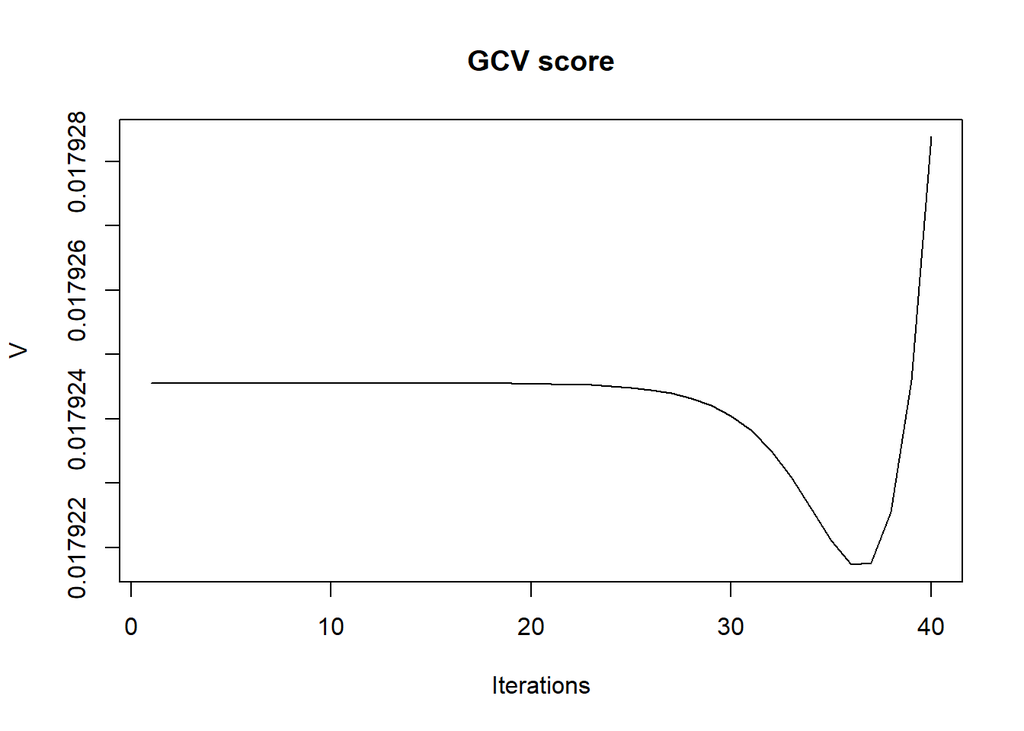

```r
lambda <- 1e-8;
iterations <- 40;
n <- length(target);
V <- rep(0,iterations)

for (i in 1:iterations) {
  mod <- prs.fit(target,x,xk,lambda) # fit model, given lambda
  trA <- sum(influence(mod)$hat[1:n]) # find tr(A)
  rss <- sum((target-fitted(mod)[1:n])^2) # residual sum of squares
  V[i] <- n*rss/(n-trA)^2 # obtain GCV score
  lambda <- lambda*1.5 #increase lambda
}
plot(1:iterations,V,type="l",main="GCV score", xlab="Iterations") # plot the score
```

```r
i <- (1:iterations) [V==min(V)]
print(noquote(paste0("Iteration: ",i,".  Optimal lambda: ",1.5^(i-1)*10^-8)))
```

```
## [1] Iteration: 36.  Optimal lambda: 0.0145610960604971
```

```r
mod.4 <- prs.fit(target,x,xk,(1.5^(i-1)*10^-8))
Xp <- spl.X(xp,xk)
```

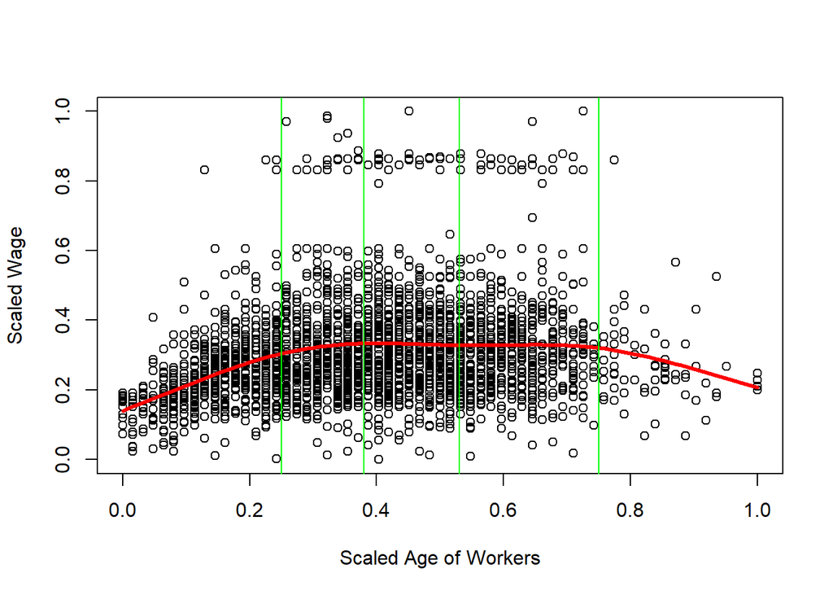

```r
plot(x,target,xlab="Scaled Age of Workers",ylab="Scaled Wage");
lines(xp,Xp%*%coef(mod.4),col="red",lwd=3)
knots <- c(0.25,0.38,0.53,0.75)
abline(v=knots[1], col="green")
abline(v=knots[2], col="green")
abline(v=knots[3], col="green")
abline(v=knots[4], col="green")
```

```r
summary(mod.4)
```

```
##
## Call:
## lm(formula = y ~ Xa - 1)
##
## Residuals:
##      Min       1Q   Median       3Q      Max
## -0.33348 -0.08153 -0.01694  0.05101  0.67525
##
## Coefficients:
##      Estimate Std. Error t value Pr(>|t|)
## Xa1   0.25433    0.01721  14.780  < 2e-16 ***
## Xa2   0.06764    0.04023   1.681  0.09284 .
## Xa3  48.14763   23.51338   2.048  0.04068 *
## Xa4  29.52158   30.82206   0.958  0.33824
## Xa5 -22.53157   23.63439  -0.953  0.34050
## Xa6  64.96908   21.30608   3.049  0.00231 **
## ---
## Signif. codes:  0 '***' 0.001 '**' 0.01 '*' 0.05 '.' 0.1 ' ' 1
##
## Residual standard error: 0.1337 on 3000 degrees of freedom
## Multiple R-squared:  0.8431, Adjusted R-squared:  0.8428
## F-statistic:  2687 on 6 and 3000 DF,  p-value: < 2.2e-16
```

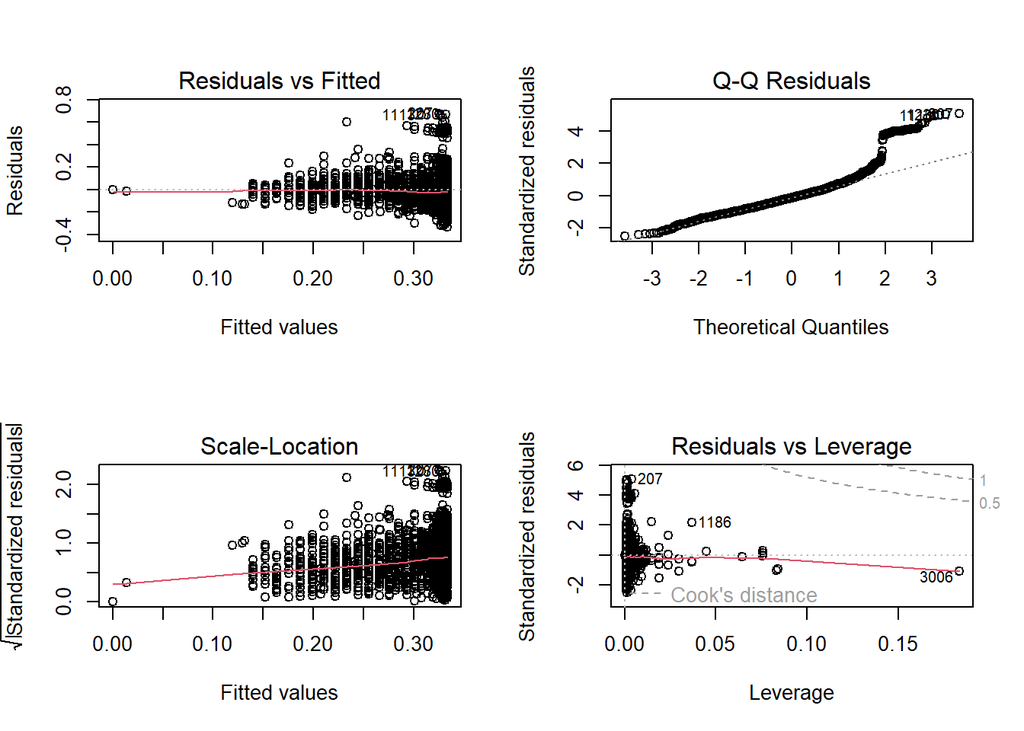

```r
par(mfrow=c(2,2))
plot(mod.4)
```

```r
#anova(mod.3,mod.4)
```

## Two Term Additive Model

Penalized regression spline representation of an additive model

```r
am.setup <- function(x, z, q=10)
# Get X, S_1, S-2 for a simple 2 term AM
{
  # spacing the knots by quantile
  xk <- quantile(unique(x), 1:(q-2)/(q-1)) # knot locations x
  zk <- quantile(unique(z), 1:(q-2)/(q-1)) # know locations z
  # get penalty matrices
  S <- list()
  S[[1]] <- S[[2]] <- matrix(0, 2*q-1, 2*q-1) # initialize two components
  S[[1]][2:q,2:q] <- spl.S(xk)[-1,-1] # penalty matrices by calling spl.S
  S[[2]][(q+1):(2*q-1),(q+1):(2*q-1)] <- spl.S(zk)[-1,-1]
  # get model matrix
  n <- length(x)
  X <- matrix(1,n,2*q-1)
  # Model matrix is constructed by combining columns of the model matrices by calling spl.X
  X[,2:q] <- spl.X(x,xk)[,-1]     # first smooth
  X[,(q+1):(2*q-1)] <- spl.X(z,zk)[,-1] # second smooth

  # matrix of the additive model.S is list containing 2 penalty matrices
  return(list(X=X,S=S))
}
```

## Fitting two-term additive model

```r
fit.am <- function(y,X,S,sp)
{
  # get sqrt of total penalty matrix
  rS <- mat.sqrt(sp[1]*S[[1]]+sp[2]*S[[2]])
  q.tot <- ncol(X) # number of params
  n <- nrow(X)  # number of data rows
  X1 <- rbind(X,rS) # augmented model matrix X
  y1 <- c(y,rep(0,q.tot)) # augment data
  b <- lm(y1~X1-1) # fit model
  trA <- sum(influence(b)$hat[1:n]) # tr(A)
  norm <- sum((y-fitted(b)[1:n])^2)
  return(list(model=b,gcv=norm*n/(n-trA)^2,sp=sp))
}
```

## Fitting data for 31 felled Cherry trees

Volume, girth, and height for 31 felled Cherry trees. We want to predict Volume using girth and height

Volume = f1(Girth) +f2(Height) + Epsilon(i)

```r
data(trees)

rg <- range(trees$Girth) # rg has low, high for girth
trees$Girth <-(trees$Girth - rg[1])/(rg[2]-rg[1]) #scaling between 0 and 1
rh <- range(trees$Height)
trees$Height <- (trees$Height - rh[1])/(rh[2]=rh[1])

# Obtaining the model matrix and penalty matrices
am0 <- am.setup(trees$Girth,trees$Height)
```

## Grid search to find model fit for minimizing the GCV score

```r
sp <- c(0,0) # initialize smoothing parameter (s.p) array
for (i in 1:30) for (j in 1:30) #loop over s.p. grid
{
  sp[1]<-1e-5*2^(i-1);
  sp[2]<-1e-5*2^(j-1) # s.p.s
  b<-fit.am(trees$Volume,am0$X,am0$S,sp) # fit using s.p.s
  if (i+j==2) best<-b else # store first model
    if(b$gcv<best$gcv) best<-b # store best model
}

best$sp
```

```
## [1]    0.01024 5368.70912
```

## Partial Effects plot scaled girth

This plot shows the effect that scaled girth has on the predicted value f_1 after zeroing out all other coefficients and making a prediction on f_1 using just scaled girth. This is a partial effects plot.

This plot also shows the fitted vs predicted values for volume.

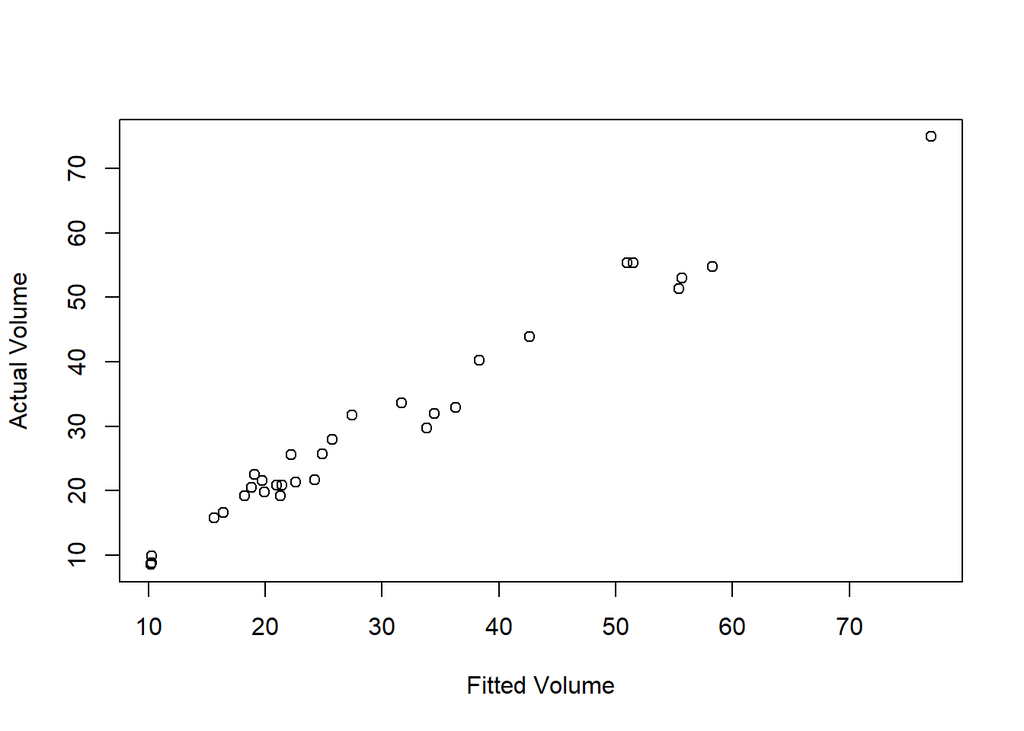

```r
# Plot fitted volume against actual volume
# Estimate of the smooth function of Girth, evaluated at the observed Girths scaled to the [0,1] interval

plot(trees$Volume, fitted(best$model)[1:31],
     xlab="Fitted Volume",ylab="Actual Volume")
```

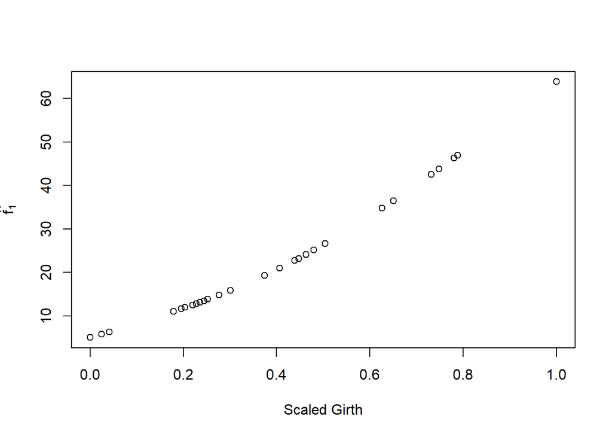

```r
# Evaluate and plot f_1 against Girth
b <- best$model
b$coefficients[1] <- 0 # zero the intercept
b$coefficients[11:19] <- 0 # zero the second smooth coefficients
f0 <- predict(b) # predict f_1 only, at data values

plot(trees$Girth,f0[1:31], xlab="Scaled Girth", ylab=expression(hat(f[1])))
```

## Partial Effects plot scaled height

This plot shows the effect that scaled height has on the predicted value f_2 after zeroing out all other coefficients and making a prediction on f_1 using just scaled height. This is a partial effects plot.

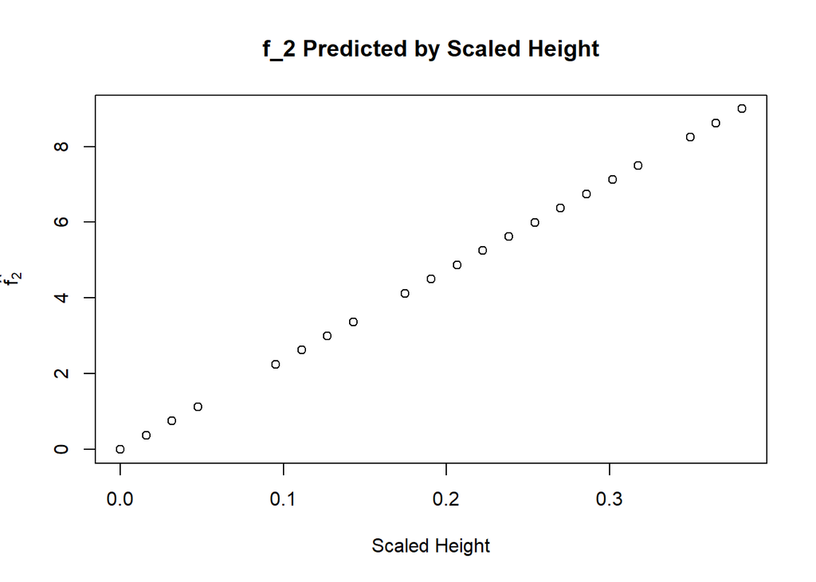

```r
# Evaluate and plot f_2 against height
# Estimate of the smooth function of Height, evaluated at the observed heights scaled to the [0,1] interval
b <- best$model
b$coefficients[1] <- 0 # zero the intercept
b$coefficients[2:10] <- 0 # zero the first smooth coeffs
f0 <- predict(b) # predict f_2 only, at data values
plot(trees$Height,f0[1:31], main="f_2 Predicted by Scaled Height", xlab="Scaled Height", ylab=expression(hat(f[2])))
```

## Continued tree data modeling using GLM with partial effect plots

Plot shows partial residuals along with confidence intervals. Intervals are using Bayesian Credible Intervals.

CIs show uncertainty from results of identifiability constraints applied to the smooth terms

identifiability constraint: the sum of the values at each curve,

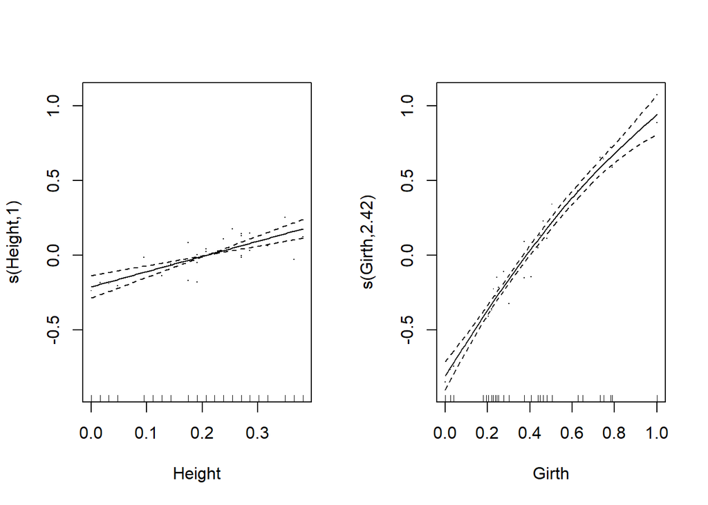

```r
# Thin plate regression splines: default smoothing spline,
  #force low-order polynomial, and dont need to know know locations

ct1 <- gam(Volume~s(Height)+s(Girth), family=Gamma(link=log), data = trees)

par(mfrow=c(1,2))
plot(ct1,residuals=TRUE) # residuals = TRUE shows partial residuals for each term
```

```r
summary(ct1)
```

```
##
## Family: Gamma
## Link function: log
##
## Formula:
## Volume ~ s(Height) + s(Girth)
##
## Parametric coefficients:
##             Estimate Std. Error t value Pr(>|t|)
## (Intercept)  3.27570    0.01492   219.6   <2e-16 ***
## ---
## Signif. codes:  0 '***' 0.001 '**' 0.01 '*' 0.05 '.' 0.1 ' ' 1
##
## Approximate significance of smooth terms:
##             edf Ref.df      F  p-value
## s(Height) 1.000  1.000  31.32 7.07e-06 ***
## s(Girth)  2.422  3.044 219.28  < 2e-16 ***
## ---
## Signif. codes:  0 '***' 0.001 '**' 0.01 '*' 0.05 '.' 0.1 ' ' 1
##
## R-sq.(adj) =  0.973   Deviance explained = 97.8%
## GCV = 0.0080824  Scale est. = 0.006899  n = 31
```

### Here I added bs=“cr” to each covariate for cubic regression spline

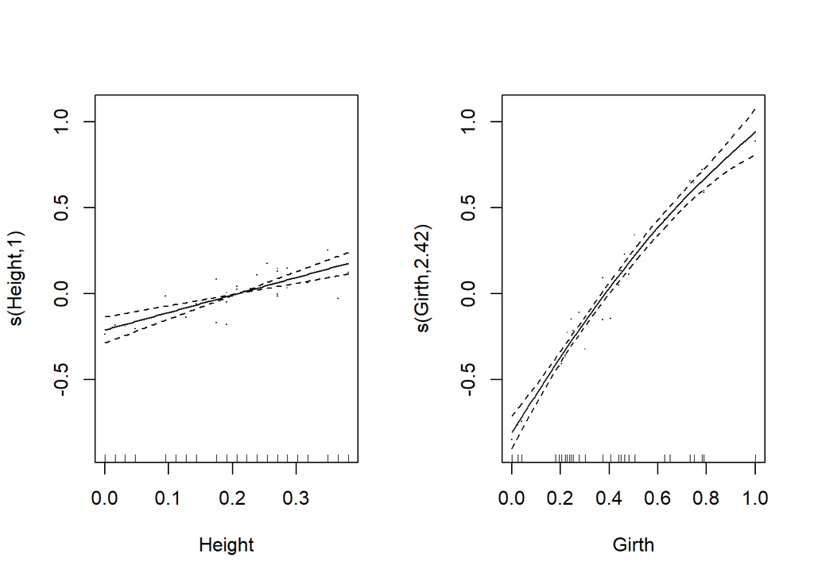

```r
ct2 <- gam(Volume~s(Height, bs="cr")+s(Girth, bs="cr"), family=Gamma(link=log), data = trees)

par(mfrow=c(1,2))
plot(ct2,residuals=TRUE) # residuals = TRUE shows partial residuals for each term
```

```r
summary(ct2)
```

```
##
## Family: Gamma
## Link function: log
##
## Formula:
## Volume ~ s(Height, bs = "cr") + s(Girth, bs = "cr")
##
## Parametric coefficients:
##             Estimate Std. Error t value Pr(>|t|)
## (Intercept)  3.27570    0.01492   219.6   <2e-16 ***
## ---
## Signif. codes:  0 '***' 0.001 '**' 0.01 '*' 0.05 '.' 0.1 ' ' 1
##
## Approximate significance of smooth terms:
##             edf Ref.df      F  p-value
## s(Height) 1.000  1.000  31.32 7.07e-06 ***
## s(Girth)  2.419  3.035 219.50  < 2e-16 ***
## ---
## Signif. codes:  0 '***' 0.001 '**' 0.01 '*' 0.05 '.' 0.1 ' ' 1
##
## R-sq.(adj) =  0.973   Deviance explained = 97.8%
## GCV = 0.0080805  Scale est. = 0.006898  n = 31
```

### Here I added k = 20 to the Girth covariate for a higher order polynomial basis for the cubic regression spline

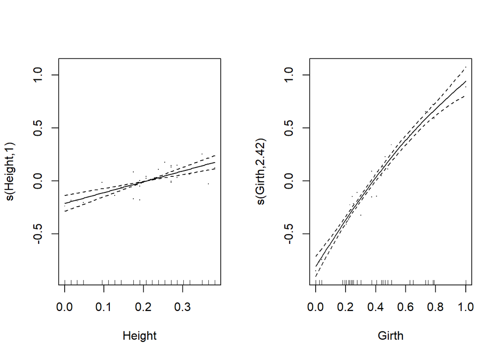

```r
library(mgcv)

ct3 <- gam(Volume~s(Height)+s(Girth, bs="cr", k = 20), family=Gamma(link=log), data = trees)

par(mfrow=c(1,2))
plot(ct3,residuals=TRUE) # residuals = TRUE shows partial residuals for each term
```

```r
summary(ct3)
```

```
##
## Family: Gamma
## Link function: log
##
## Formula:
## Volume ~ s(Height) + s(Girth, bs = "cr", k = 20)
##
## Parametric coefficients:
##             Estimate Std. Error t value Pr(>|t|)
## (Intercept)  3.27570    0.01492   219.6   <2e-16 ***
## ---
## Signif. codes:  0 '***' 0.001 '**' 0.01 '*' 0.05 '.' 0.1 ' ' 1
##
## Approximate significance of smooth terms:
##             edf Ref.df      F  p-value
## s(Height) 1.000  1.000  31.31 7.08e-06 ***
## s(Girth)  2.424  3.049 218.92  < 2e-16 ***
## ---
## Signif. codes:  0 '***' 0.001 '**' 0.01 '*' 0.05 '.' 0.1 ' ' 1
##
## R-sq.(adj) =  0.973   Deviance explained = 97.8%
## GCV = 0.008083  Scale est. = 0.006899  n = 31
```

### Here I added the gamma parameter which controls how much each degreee of freedom contributes to GCV score

Adjusting this can help protect against overfitting the model, without comprimising model fit.

Increasing gamma causes heavier penalty for each degree of freedom in GCV score

Resulting in model with fewer DF.

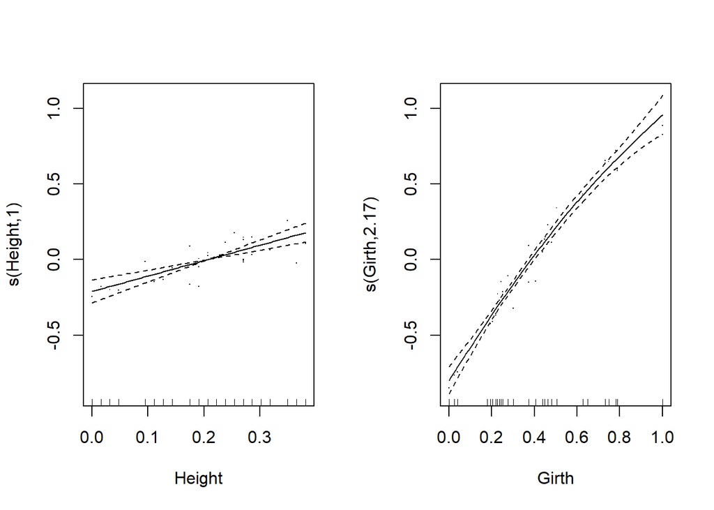

```r
ct4 <- gam(Volume~s(Height)+s(Girth), family=Gamma(link=log), data = trees, gamma=1.4)

par(mfrow=c(1,2))
plot(ct4,residuals=TRUE) # residuals = TRUE shows partial residuals for each term
```

```r
summary(ct4)
```

```
##
## Family: Gamma
## Link function: log
##
## Formula:
## Volume ~ s(Height) + s(Girth)
##
## Parametric coefficients:
##             Estimate Std. Error t value Pr(>|t|)
## (Intercept)  3.27577    0.01504   217.8   <2e-16 ***
## ---
## Signif. codes:  0 '***' 0.001 '**' 0.01 '*' 0.05 '.' 0.1 ' ' 1
##
## Approximate significance of smooth terms:
##            edf Ref.df      F p-value
## s(Height) 1.00  1.000  31.51 6.8e-06 ***
## s(Girth)  2.17  2.735 237.10 < 2e-16 ***
## ---
## Signif. codes:  0 '***' 0.001 '**' 0.01 '*' 0.05 '.' 0.1 ' ' 1
##
## R-sq.(adj) =  0.972   Deviance explained = 97.7%
## GCV = 0.009228  Scale est. = 0.0070127  n = 31
```

### This code smooths more than one predictor: Isotropic

If you have different scales, get a better estimate using a tensor product.

Isotropic is better if the variates are on the same scale. This is a isotropic model: s()

```
##
## Family: Gamma
## Link function: log
##
## Formula:
## Volume ~ s(Height, Girth, k = 25)
##
## Parametric coefficients:
##             Estimate Std. Error t value Pr(>|t|)
## (Intercept)   3.2757     0.0152   215.5   <2e-16 ***
## ---
## Signif. codes:  0 '***' 0.001 '**' 0.01 '*' 0.05 '.' 0.1 ' ' 1
##
## Approximate significance of smooth terms:
##                  edf Ref.df     F p-value
## s(Height,Girth) 4.13  5.468 207.1  <2e-16 ***
## ---
## Signif. codes:  0 '***' 0.001 '**' 0.01 '*' 0.05 '.' 0.1 ' ' 1
##
## R-sq.(adj) =   0.97   Deviance explained = 97.8%
## GCV = 0.0085571  Scale est. = 0.0071619  n = 31
```

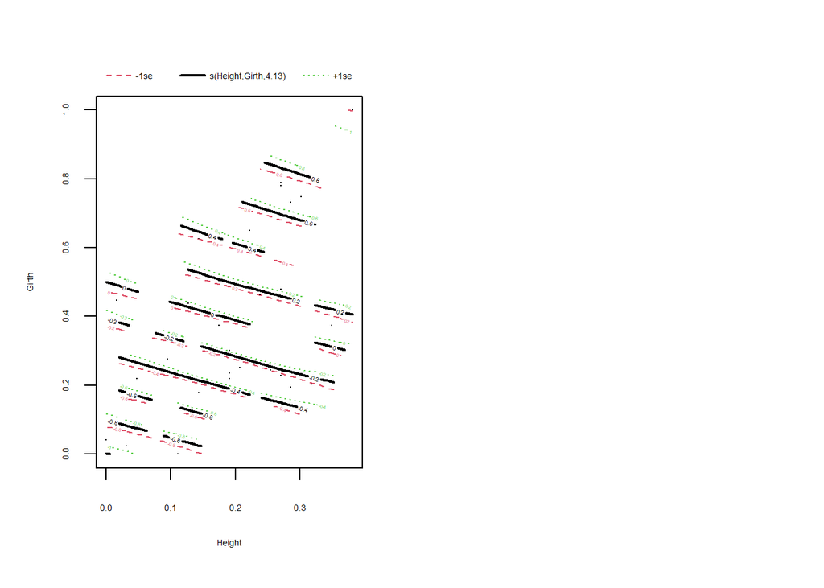

```r
ct5 <- gam(Volume~s(Height, Girth, k=25), family=Gamma(link=log), data = trees)

par(mfrow=c(1,2))
plot(ct5,residuals=TRUE) # residuals = TRUE shows partial residuals for each term

summary(ct5)
```

### This code smooths more than one predictor: tensor product

If you have different scales, get a better estimate using a tensor product.

The tensor product is used as: te(). TP is scale invarient.

```
##
## Family: Gamma
## Link function: log
##
## Formula:
## Volume ~ te(Height, Girth, k = 5)
##
## Parametric coefficients:
##             Estimate Std. Error t value Pr(>|t|)
## (Intercept)  3.27584    0.01522   215.2   <2e-16 ***
## ---
## Signif. codes:  0 '***' 0.001 '**' 0.01 '*' 0.05 '.' 0.1 ' ' 1
##
## Approximate significance of smooth terms:
##                  edf Ref.df     F p-value
## te(Height,Girth)   3      3 377.2  <2e-16 ***
## ---
## Signif. codes:  0 '***' 0.001 '**' 0.01 '*' 0.05 '.' 0.1 ' ' 1
##
## R-sq.(adj) =  0.973   Deviance explained = 97.7%
## GCV = 0.0081971  Scale est. = 0.0071821  n = 31
```

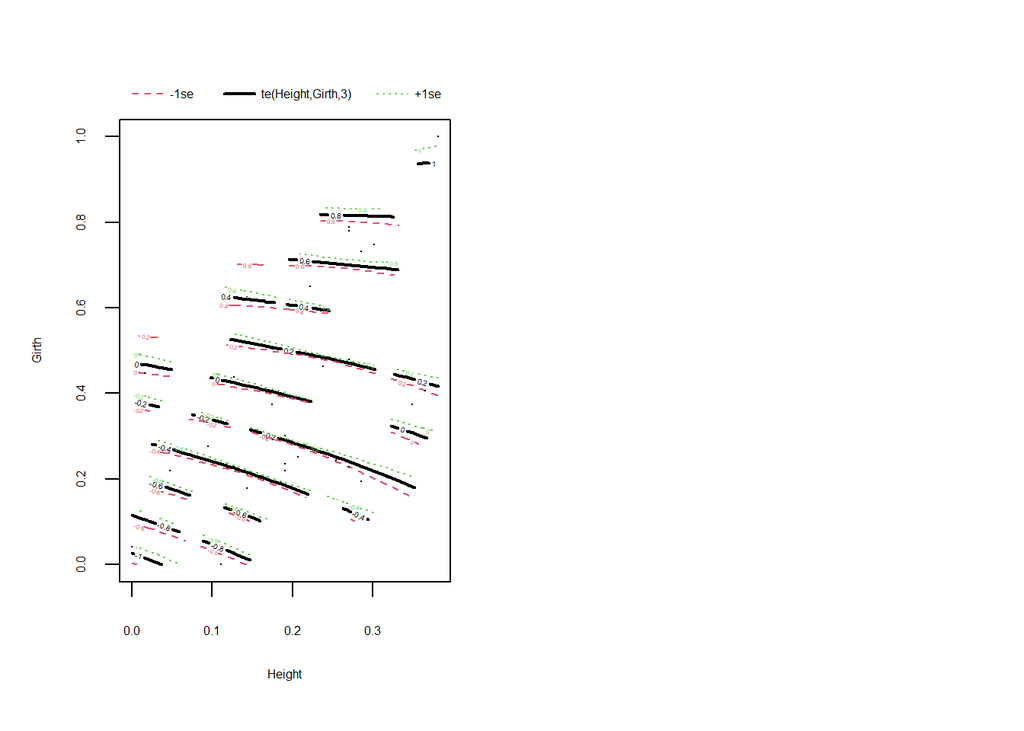

```r
ct6 <- gam(Volume~te(Height, Girth, k=5), family=Gamma(link=log), data = trees)

par(mfrow=c(1,2))
plot(ct6,residuals=TRUE) # residuals = TRUE shows partial residuals for each term

summary(ct6)
```

### Using a factor variable as a predictor

Mixing parametric ans smooth terms

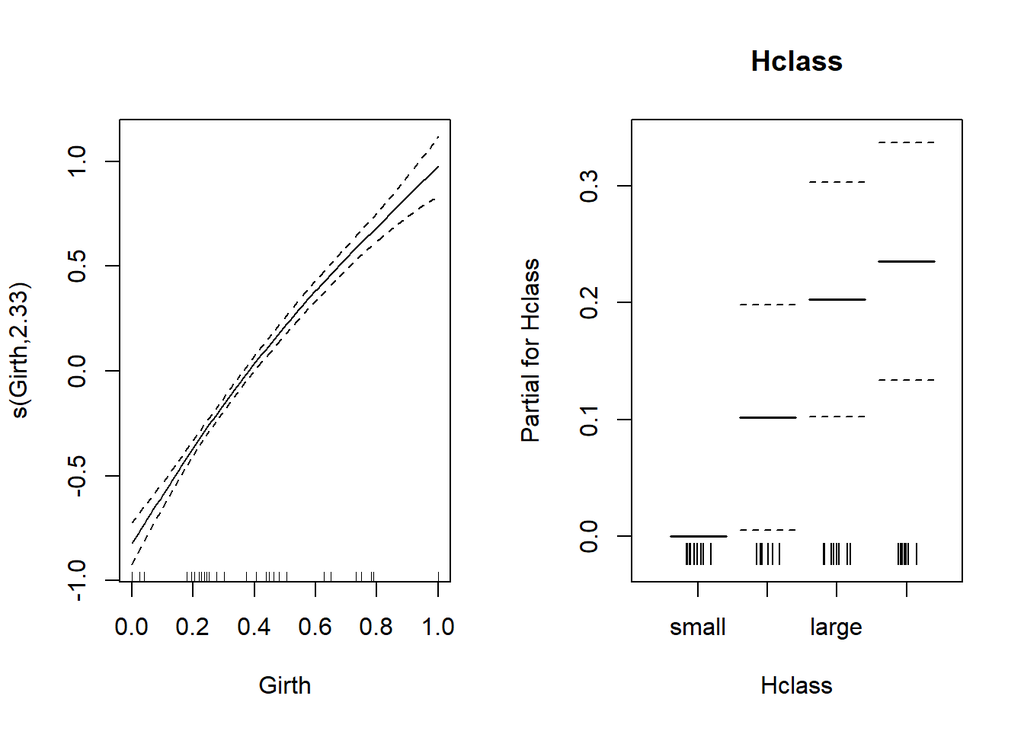

```r
qnt <- quantile(trees$Height,seq(0,1,0.25))
trees$Hclass <- factor(cut(trees$Height,unique(qnt),include.lowest=TRUE),labels=c("small","medium","large","very large"))

ct7 <- gam(Volume ~ Hclass+s(Girth), family=Gamma(link=log), data = trees)

par(mfrow=c(1,2))
plot(ct7,all.terms=T) # residuals = TRUE shows partial residuals for each term
```

```r
summary(ct7)
```

```
##
## Family: Gamma
## Link function: log
##
## Formula:
## Volume ~ Hclass + s(Girth)
##
## Parametric coefficients:
##                  Estimate Std. Error t value Pr(>|t|)
## (Intercept)       3.14740    0.03302  95.311  < 2e-16 ***
## Hclassmedium      0.10193    0.04838   2.107 0.045468 *
## Hclasslarge       0.20295    0.05022   4.041 0.000455 ***
## Hclassvery large  0.23532    0.05085   4.628 0.000101 ***
## ---
## Signif. codes:  0 '***' 0.001 '**' 0.01 '*' 0.05 '.' 0.1 ' ' 1
##
## Approximate significance of smooth terms:
##            edf Ref.df     F p-value
## s(Girth) 2.334  2.941 193.4  <2e-16 ***
## ---
## Signif. codes:  0 '***' 0.001 '**' 0.01 '*' 0.05 '.' 0.1 ' ' 1
##
## R-sq.(adj) =  0.973   Deviance explained = 97.6%
## GCV = 0.010101  Scale est. = 0.0080594  n = 31
```